# House Selling Price

# **Model Validation**:

My model so far has achieved a **Validation Adjusted R^2 of 0.8327** and a **Validation R^2 of 0.8596** .

# *Code and Table of Results*:

```r
library(readr)
library(ggplot2)
library(pander)
library(tidyverse)
library(plotly)
library(reshape2)

train <- read.csv("../Data/train.csv", stringsAsFactors = TRUE)

train <- train %>%
  mutate(TotalSF = X1stFlrSF + X2ndFlrSF + TotalBsmtSF,
         RichNbrhd = case_when(Neighborhood %in% c("StoneBr", "NridgHt", "NoRidge") ~ 1, TRUE ~ 0),
         Alley = replace_na(as.character(Alley), "None"),
         Alley = as.factor(Alley))

set.seed(121)
num_rows <- 1000
keep <- sample(1:nrow(train), num_rows)

mytrain <- train[keep, ]
mytest <- train[-keep, ]

lm_model <- lm(SalePrice ~ TotalSF + RichNbrhd + YearBuilt + WoodDeckSF + FullBath + BsmtQual + Neighborhood + HouseStyle + OverallQual + OverallCond + BsmtCond + TotalBsmtSF +
                 TotalSF:RichNbrhd + TotalSF:Fireplaces + TotalSF:Neighborhood + TotalSF:OverallCond + TotalSF:TotalBsmtSF, data=mytrain)
pander(summary(lm_model))
```

|  | Estimate | Std. Error | t value | Pr(>\|t\|) |
| --- | --- | --- | --- | --- |
| **(Intercept)** | -1111552 | 176639 | -6.293 | 4.868e-10 |
| **TotalSF** | 80.41 | 39.38 | 2.042 | 0.04147 |
| **RichNbrhd** | -121784 | 113843 | -1.07 | 0.285 |
| **YearBuilt** | 512.8 | 69.78 | 7.348 | 4.527e-13 |
| **WoodDeckSF** | 16.41 | 6.951 | 2.36 | 0.01847 |
| **FullBath** | 1206 | 2543 | 0.474 | 0.6356 |
| **BsmtQualFa** | -33407 | 7338 | -4.553 | 6.03e-06 |
| **BsmtQualGd** | -36587 | 3914 | -9.347 | 6.933e-20 |
| **BsmtQualTA** | -35416 | 4833 | -7.328 | 5.194e-13 |
| **NeighborhoodBlueste** | 21566 | 48495 | 0.4447 | 0.6566 |
| **NeighborhoodBrDale** | 86632 | 120906 | 0.7165 | 0.4739 |
| **NeighborhoodBrkSide** | 119843 | 111929 | 1.071 | 0.2846 |
| **NeighborhoodClearCr** | 63954 | 118041 | 0.5418 | 0.5881 |
| **NeighborhoodCollgCr** | 86155 | 110955 | 0.7765 | 0.4377 |
| **NeighborhoodCrawfor** | 136357 | 111803 | 1.22 | 0.2229 |
| **NeighborhoodEdwards** | 167508 | 110824 | 1.511 | 0.131 |
| **NeighborhoodGilbert** | 52224 | 112179 | 0.4655 | 0.6417 |
| **NeighborhoodIDOTRR** | 94784 | 115410 | 0.8213 | 0.4117 |
| **NeighborhoodMeadowV** | 134033 | 112500 | 1.191 | 0.2338 |
| **NeighborhoodMitchel** | 117917 | 111938 | 1.053 | 0.2924 |
| **NeighborhoodNAmes** | 136988 | 110718 | 1.237 | 0.2163 |
| **NeighborhoodNoRidge** | 56268 | 35251 | 1.596 | 0.1108 |
| **NeighborhoodNPkVill** | 166470 | 172379 | 0.9657 | 0.3344 |
| **NeighborhoodNridgHt** | 20768 | 34308 | 0.6053 | 0.5451 |
| **NeighborhoodNWAmes** | 99850 | 111689 | 0.894 | 0.3716 |
| **NeighborhoodOldTown** | 131950 | 110993 | 1.189 | 0.2348 |
| **NeighborhoodSawyer** | 140505 | 111575 | 1.259 | 0.2083 |
| **NeighborhoodSawyerW** | 101359 | 111589 | 0.9083 | 0.3639 |
| **NeighborhoodSomerst** | 70926 | 111416 | 0.6366 | 0.5246 |
| **NeighborhoodSWISU** | 160927 | 112443 | 1.431 | 0.1527 |
| **NeighborhoodTimber** | 36912 | 112948 | 0.3268 | 0.7439 |
| **NeighborhoodVeenker** | -115610 | 126479 | -0.9141 | 0.3609 |
| **HouseStyle1.5Unf** | 3455 | 8500 | 0.4064 | 0.6845 |
| **HouseStyle1Story** | 9225 | 3895 | 2.369 | 0.01807 |
| **HouseStyle2.5Fin** | -582 | 13263 | -0.04388 | 0.965 |
| **HouseStyle2.5Unf** | -121.3 | 11037 | -0.01099 | 0.9912 |
| **HouseStyle2Story** | -219.6 | 3566 | -0.06159 | 0.9509 |
| **HouseStyleSFoyer** | 12212 | 6876 | 1.776 | 0.07609 |
| **HouseStyleSLvl** | 15405 | 5562 | 2.77 | 0.005724 |
| **OverallQual** | 10408 | 1152 | 9.033 | 9.987e-19 |
| **OverallCond** | -1166 | 2703 | -0.4313 | 0.6663 |
| **BsmtCondGd** | 2819 | 6253 | 0.4508 | 0.6522 |
| **BsmtCondPo** | 3826 | 19550 | 0.1957 | 0.8449 |
| **BsmtCondTA** | 3185 | 5051 | 0.6306 | 0.5284 |
| **TotalBsmtSF** | -15.57 | 10.31 | -1.511 | 0.1311 |
| **TotalSF:RichNbrhd** | 48.05 | 39.58 | 1.214 | 0.2251 |
| **TotalSF:Fireplaces** | 3.728 | 0.5821 | 6.403 | 2.446e-10 |
| **TotalSF:NeighborhoodBrDale** | -34.98 | 47.49 | -0.7365 | 0.4616 |
| **TotalSF:NeighborhoodBrkSide** | -37.8 | 39.79 | -0.95 | 0.3424 |
| **TotalSF:NeighborhoodClearCr** | -15.75 | 41.12 | -0.383 | 0.7018 |
| **TotalSF:NeighborhoodCollgCr** | -25.43 | 38.95 | -0.653 | 0.5139 |
| **TotalSF:NeighborhoodCrawfor** | -39.72 | 39.18 | -1.014 | 0.311 |
| **TotalSF:NeighborhoodEdwards** | -64.66 | 38.92 | -1.661 | 0.09699 |
| **TotalSF:NeighborhoodGilbert** | -14.13 | 39.51 | -0.3577 | 0.7206 |
| **TotalSF:NeighborhoodIDOTRR** | -29.52 | 42.58 | -0.6934 | 0.4882 |
| **TotalSF:NeighborhoodMeadowV** | -63.43 | 40.57 | -1.563 | 0.1183 |
| **TotalSF:NeighborhoodMitchel** | -45.37 | 39.4 | -1.152 | 0.2498 |
| **TotalSF:NeighborhoodNAmes** | -50.89 | 38.86 | -1.309 | 0.1907 |
| **TotalSF:NeighborhoodNoRidge** | -25.85 | 9.747 | -2.652 | 0.008144 |
| **TotalSF:NeighborhoodNPkVill** | -69.39 | 71.88 | -0.9654 | 0.3346 |
| **TotalSF:NeighborhoodNridgHt** | -10.28 | 9.931 | -1.035 | 0.3011 |
| **TotalSF:NeighborhoodNWAmes** | -37.86 | 39.17 | -0.9668 | 0.3339 |
| **TotalSF:NeighborhoodOldTown** | -49.08 | 39.04 | -1.257 | 0.209 |
| **TotalSF:NeighborhoodSawyer** | -53.62 | 39.38 | -1.362 | 0.1736 |
| **TotalSF:NeighborhoodSawyerW** | -32.78 | 39.16 | -0.837 | 0.4028 |
| **TotalSF:NeighborhoodSomerst** | -15.67 | 39.12 | -0.4005 | 0.6889 |
| **TotalSF:NeighborhoodSWISU** | -58.88 | 39.67 | -1.484 | 0.138 |
| **TotalSF:NeighborhoodTimber** | -9.162 | 39.46 | -0.2322 | 0.8164 |
| **TotalSF:NeighborhoodVeenker** | 51.96 | 44.09 | 1.178 | 0.239 |
| **TotalSF:OverallCond** | 3.674 | 1.09 | 3.37 | 0.0007826 |
| **TotalSF:TotalBsmtSF** | -0.008073 | 0.002233 | -3.615 | 0.0003171 |

Fitting linear model: SalePrice ~ TotalSF + RichNbrhd + YearBuilt + WoodDeckSF + FullBath + BsmtQual + Neighborhood + HouseStyle + OverallQual + OverallCond + BsmtCond + TotalBsmtSF + TotalSF:RichNbrhd + TotalSF:Fireplaces + TotalSF:Neighborhood + TotalSF:OverallCond + TotalSF:TotalBsmtSF

| Observations | Residual Std. Error | $R^2$ | Adjusted $R^2$ |
| --- | --- | --- | --- |
| 969 | 24841 | 0.9134 | 0.9066 |

```r
predicted <- predict(lm_model, newdata=mytest)

predicted <- ifelse(is.na(predicted), mean(predicted, na.rm = TRUE), predicted)

ybar <- mean(mytest$SalePrice)

SSTO <- sum((mytest$SalePrice - ybar)^2)
SSE <- sum((mytest$SalePrice - predicted)^2)

r_squared <- 1 - SSE / SSTO
n <- nrow(mytest)
p <- length(coef(lm_model))
adj_r_squared <- 1 - ((n - 1) / (n - p -1)) * (SSE / SSTO)

validation_results <- data.frame(
  Model = "My Model",
  `Original R^2` = summary(lm_model)$r.squared,
  `Original Adj. R^2` = summary(lm_model)$adj.r.squared,
  `Validation R^2` = r_squared,
  `Validation Adj. R^2` = adj_r_squared
)

knitr::kable(validation_results, digits = 4)
```

| Model | Original.R.2 | Original.Adj..R.2 | Validation.R.2 | Validation.Adj..R.2 |
| --- | --- | --- | --- | --- |
| My Model | 0.9134 | 0.9066 | 0.8596 | 0.8327 |

# *Visualizing the model:*

## SalePrice vs TotalSF:

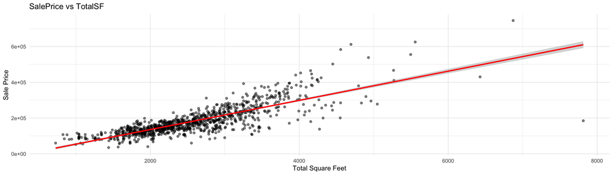

```r
ggplot(mytrain, aes(x = TotalSF, y = SalePrice)) +
  geom_point(alpha = 0.5) +
  geom_smooth(method = "lm", color = "red") +
  labs(title = "SalePrice vs TotalSF", x = "Total Square Feet", y = "Sale Price") +
  theme_minimal()
```

This scatter plot is visualizing the relationship between a house’s total square footage and its sale price, labeled **SalePrice vs TotalSF** The grey dots are all each corresponding to a specific house. There’s a clear upward trend, indicating a positive correlation between these two variables: as the square footage increases, the sale price generally increases as well. A red line has been fitted to the data, suggesting a linear relationship and potentially representing a linear regression model. While the trend is evident, the scatter of the points shows that other factors influence sale price beyond just square footage.

## My 3D Scatterplot of SalePrice vs TotalSF & OverallQual

```r
library(plotly)
plot_ly(mytrain, x = ~TotalSF, y = ~OverallQual, z = ~SalePrice, type = "scatter3d", mode = "markers",
        marker = list(size = 3, color = ~SalePrice, colorscale = "Viridis")) %>%
  layout(title = "3D Scatter: SalePrice vs TotalSF & OverallQual",
         scene = list(xaxis = list(title = "TotalSF"),
                      yaxis = list(title = "OverallQual"),
                      zaxis = list(title = "SalePrice")))
```

[interactive chart not shown]

This 3D scatter plot illustrates the relationship between Sale Price, Total Square Feet (TotalSF), and Overall Quality (OverallQual) of houses, revealing a strong positive correlation across all three variables. **As both TotalSF and OverallQual increase, SalePrice tends to rise**, indicating that larger, higher-quality homes command higher prices. The data points cluster in the lower ranges, but distinct outliers, especially those with high SalePrice and OverallQual, suggest premium properties.

## Another 3D Scatterplot of SalePrice vs RichNbrhd & YearBuilt

```r
library(plotly)
plot_ly(mytrain, x = ~RichNbrhd, y = ~YearBuilt, z = ~SalePrice, type = "scatter3d", mode = "markers",
        marker = list(size = 3, color = ~SalePrice, colorscale = "Viridis")) %>%
  layout(title = "3D Scatter: SalePrice vs TotalSF & OverallQual",
         scene = list(xaxis = list(title = "RichNbrhd"),
                      yaxis = list(title = "YearBuilt"),
                      zaxis = list(title = "SalePrice")))
```

[interactive chart not shown]

This 3D scatter plot illustrates the relationship between **SalePrice**, **YearBuilt**, and **RichNbrhd**. It suggests a potential trend where newer houses (higher YearBuilt) in richer neighborhoods (higher RichNbrhd) tend to have higher SalePrices. The data points show a concentration towards the lower end of RichNbrhd, indicating that most properties are not in the “rich” neighborhoods. However, there is a noticeable spread of SalePrices across different YearBuilt values, with some newer homes showing significantly higher prices.

## One final 3D Scatterplot showing Saleprice vs OverallCond & FullBath

```r
library(plotly)
plot_ly(mytrain, x = ~OverallCond, y = ~FullBath, z = ~SalePrice, type = "scatter3d", mode = "markers",
        marker = list(size = 3, color = ~SalePrice, colorscale = "Viridis")) %>%
  layout(title = "3D Scatter: SalePrice vs TotalSF & OverallQual",
         scene = list(xaxis = list(title = "RichNbrhd"),
                      yaxis = list(title = "OverallCond"),
                      zaxis = list(title = "FullBath")))
```

[interactive chart not shown]

# *Diagnostic Plots:*

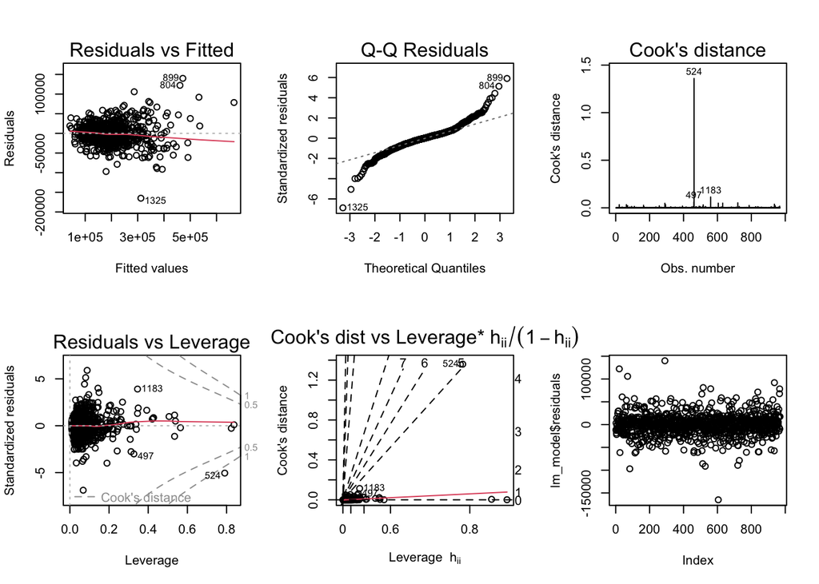

```r
par(mfrow=c(2,3))
plot(lm_model, which = c(1,2,4,5, 6))
plot(lm_model$residuals)
```

**Cook’s Distance:** This shows if any single point has a big influence. Point 524 has a very big influence.

**Residuals vs Leverage:** This finds points that are both far away from the others and have big errors. Points 524, 497, and 1183 are like this.

**Cook’s dist vs Leverage:** Another way to see those influential points. Point 524 is still the biggest problem.

# *Discussion of Validation results and Coefficients:*

## Validation Results:

**Original Adjusted R²** (0.9066): Indicates the model explains 90.66% of the variance in house prices, adjusting for predictors.

**Validation Adjusted R²** (0.8327): Shows how well the model generalizes to new data. A decrease from the original suggests slight overfitting, but 0.8327 still indicates strong model performance on unseen data.

**Validation R²** (0.8596) measures the proportion of variance in the validation data explained by the model. A high value indicates good predictive performance, though it doesn’t adjust for the number of predictors, so it’s best considered alongside adjusted R².

## Coefficents Interpretation:

**TotalSF:** Indicates how much SalePrice changes per additional square foot of total space.

**RichNbrhd:** Shows the price difference for houses in wealthy neighborhoods compared to others.

**OverallQual:** Denotes the overall quality of a given home. Similar to **OverallCond**, which indicates the condition of a home.

**Interaction terms:** For example, TotalSF:RichNbrhd shows how the effect of square footage on price changes in wealthy neighborhoods.

There are other coefficents used, but I felt these were the most impactful on my model and led to me acheiving the highest R-squared value.